# Saccoloma Leaf Age @ La Selva 2017

## Summary

Here we measured gas exchange and chlorophyll content on different age classes of Saccoloma at La Selva. Each individual (n=25) had fronds with ages classes of 1 to 4 years. Below are the boxplots (excluding outliers) of photosynthesis (A<sub>n</sub>), stomatal conductance (g<sub>s</sub>), instantaneous water use efficiency (ITE), transpiration (E<sub>l</sub>) and chlorophyll content. Gas exchange was performed on a subset of individuals (n=10). For clarity I have colored the age classes in the manner they are marked in the field.

There is an issue with Year 2 & 3 gas exchange data from #26 . Something went wrong on the water side of gas exchange, although A<sub>n</sub> looks alright. I have deleted it for the moment. I have pasted the raw data that was deleted at the bottom so you can have a look.

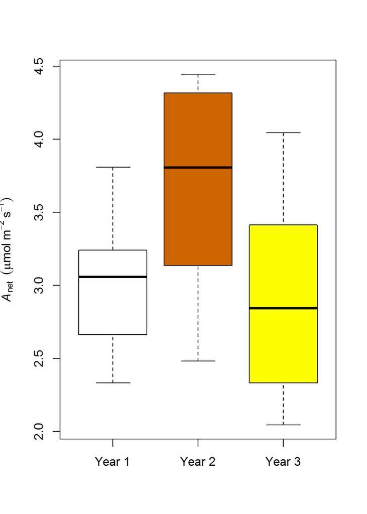

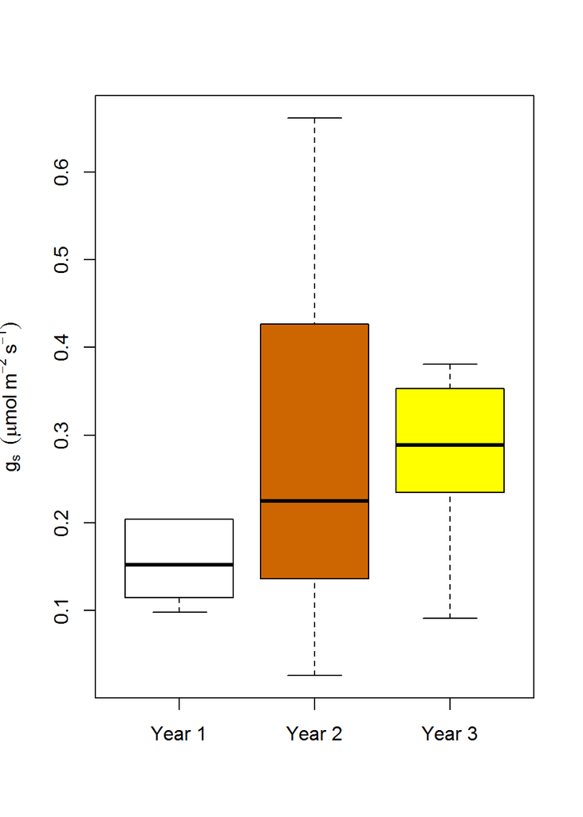

A<sub>n</sub> seems to be higher in year 2 but there is a lot of variation within other years. Stomatal conductance may be higher in year 3, despite a ton of variation in year 2. Ill run some stats sonon.

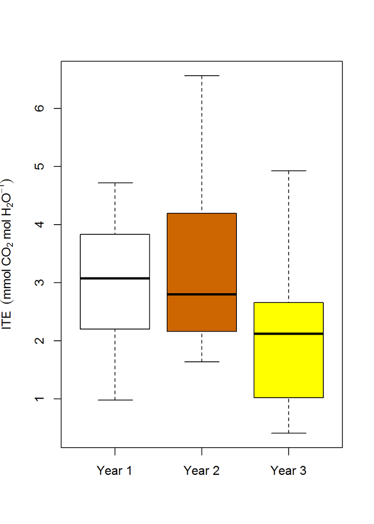

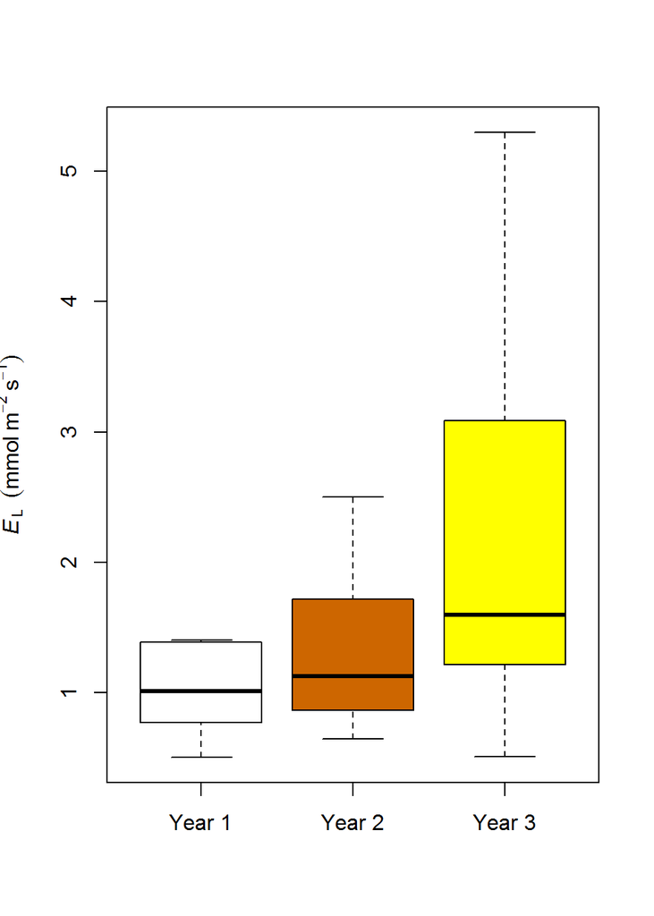

Instantaneous water use efficiency looks like it declines in year 3. Looks to be mostly driven by water loss instead of A<sub>n</sub>

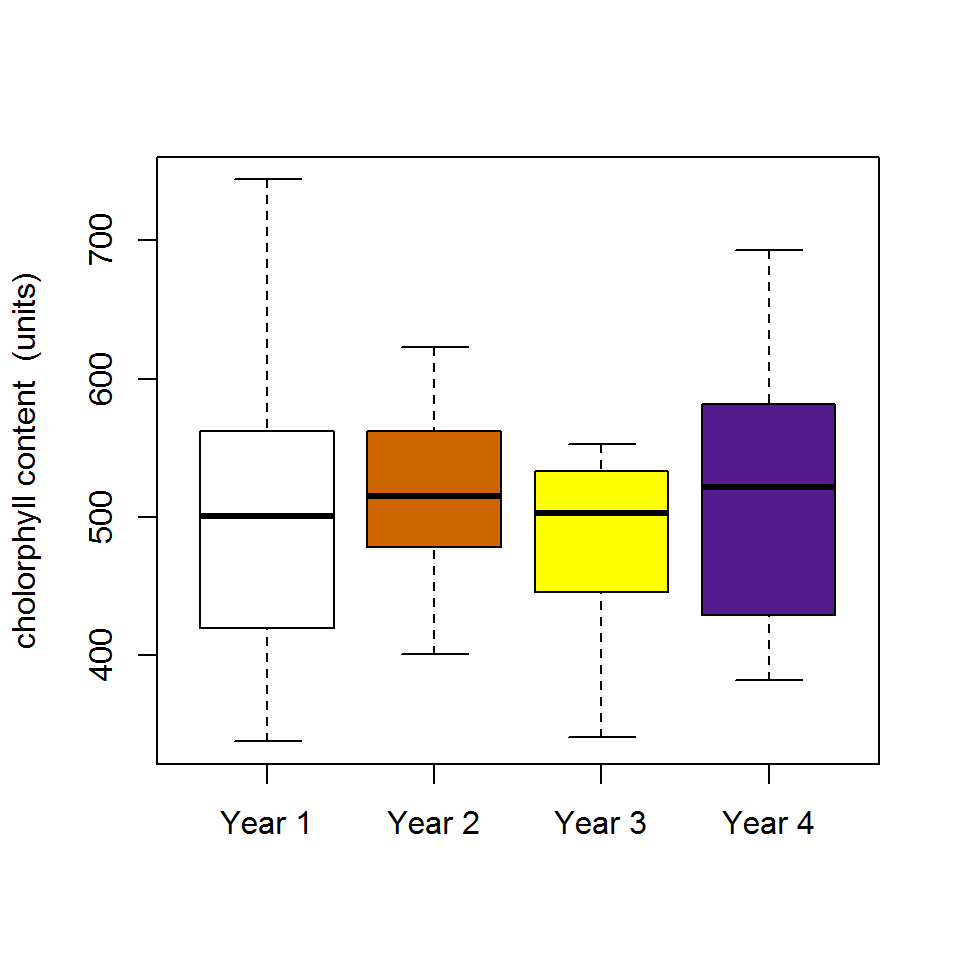

No obvious changes in chlorophyll content. It will be interesting to see what happens with leaf nitrogen.

### Transpiration data is bad for certain ages for #26

```r
photo[photo$Indiv == 26, c("Indiv", "leafage", "Photo", "Cond", "Trmmol", "Ci")]
```

```
##     Indiv leafage    Photo          Cond      Trmmol            Ci
## 126    26       2 2.824424  0.0467552410  0.23189451    295.715372
## 127    26       2 2.904937  0.0485611620  0.24026454    296.610524
## 128    26       2 2.892093  0.0500839140  0.24733693    299.905604
## 129    26       2 2.842304  0.0502742630  0.24760333    301.860485
## 130    26       2 2.914478  0.0517182150  0.25459295    302.094215
## 131    26       1 4.609996  0.2362055310  1.17445255    359.434307
## 132    26       1 5.005046  0.2324258900  1.15506460    356.139980
## 133    26       1 6.115575  0.2313381200  1.14665426    348.475770
## 134    26       1 5.158546  0.2273796340  1.12857218    355.295895
## 135    26       1 4.904599  0.2275963160  1.12539941    357.250962
## 136    26       1 4.955464  0.2255612680  1.11609797    356.567020
## 137    26       1 4.832140  0.2234482030  1.10621043    357.190813
## 138    26       1 4.901738  0.2208490720  1.09297862    356.095426
## 139    26       3 3.501050 -0.1181561320 -0.89533178    436.375503
## 140    26       3 4.299755 -0.0852055030 -0.59366998    470.254426
## 141    26       3 3.802566 -0.0594606650 -0.39221844    492.464190
## 142    26       3 3.752104 -0.0360556300 -0.22764603    556.507654
## 143    26       3 3.652737 -0.0153640860 -0.09336252    769.503156
## 144    26       3 3.646284  0.0000989768  0.00058572 -58274.990560
## 145    26       3 3.728219  0.0148844010  0.08604899     -8.000332
```